# Lesson 9 - ggplot2

Stats 20 – Section 1 – Vivian Lew

7/09/2020

# Introduction to Lesson 9

Visualizations created using ggplot2 shouldn’t be simple (otherwise, just use base R plot() or qplot() – quick plot from ggplot2). They should have a richness that is not easily programmed in plot() – mostly because that richness can be achieved with the addition of a few simple options.

Lesson 9 is about taking the basic statistical graphics that you’ve seen in your first stats course, re-doing them using ggplot, and then using ggplot’s many additional features to polish them for presentation. One of the awards given at DataFest is “Best Data Visualization” and ggplot has been used by most of the winners.

Packages and data used :

```r
library(tidyverse)
library(gridExtra)
library(ggthemes)
load("Lesson9SU.RData")
```

# 1. Scatterplot (2 numeric variables)

Here’s a basic ggplot generated scatterplot of a player’s weight on height colored by the position they play in the sport. We will then add a single regression line through all of the data points:

First we prepare the data by performing an inner join to connect information on the players with their salaries:

```r
test <- inner_join(nbaall, salary, by = "Player")
```

Let’s check test before moving forward:

```r
head(test)
```

```
##                     Player From   To Pos   Ht  Wt        Birth Date
## 1             Jaylen Adams 2019 2019   G  6-2 190       May 4, 1996
## 2             Steven Adams 2014 2020   C 6-11 265     July 20, 1993
## 3              Bam Adebayo 2018 2020 C-F  6-9 255     July 18, 1997
## 4             Cole Aldrich 2011 2018   C 6-11 250  October 31, 1988
## 5        LaMarcus Aldridge 2007 2020 F-C 6-11 260     July 19, 1985
## 6 Nickeil Alexander-Walker 2020 2020   G  6-5 205 September 2, 1998
##          Colleges Rank Team Salary2019-20 Salary2020-21 Salary2021-22
## 1 St. Bonaventure  521  ATL        100000            NA            NA
## 2            Pitt   41  OKC      25842697      27528090            NA
## 3        Kentucky  253  MIA       3454080       5115492            NA
## 4          Kansas  478  MIN        685340        685340            NA
## 5           Texas   40  SAS      26000000      24000000            NA
## 6   Virginia Tech  270  NOP       2964840       3113160       3261480
##   Salary2022-23 Salary2023-24 Salary2024-25    SignedUsing Guaranteed
## 1            NA            NA            NA                    100000
## 2            NA            NA            NA 1st Round Pick   53370787
## 3            NA            NA            NA 1st Round Pick    8569572
## 4            NA            NA            NA                   1370680
## 5            NA            NA            NA      Cap Space   50000000
## 6       5009633            NA            NA 1st Round Pick    6078000
```

Next, we create new variables from existing variables. This is done because the data may not be in the correct format for plotting, so we use our data management skills to make necessary modifications:

```r
test <- test %>%
  mutate(weight = as.numeric(Wt),
         height = (as.numeric(substr(test$Ht, start = 1, stop = 1)) * 12) +
           (as.numeric(substr(test$Ht, start = 3, stop = 4))))
```

We are basically modifying the data frame test by adding two new variables, weight and height. Both weight and height were saved as character variables, all we are doing is transforming them.

The function substr() is what is known as a “string” function and we will examine those in Week 4. For now, just know that substr() takes a character vector as input and then start = and stop = refer to the position within that string that we wish to extract.

Here is a simpler example:

```r
junk <- c("UCLA", "USC", "STANFORD")
substr(junk, start = 1, stop = 2)
```

```
## [1] "UC" "US" "ST"
```

so if you study the code for height, you will see that we are extracting the first number and the last two and performing the appropriate math to convert it into inches.

Now we can finally create our plot:

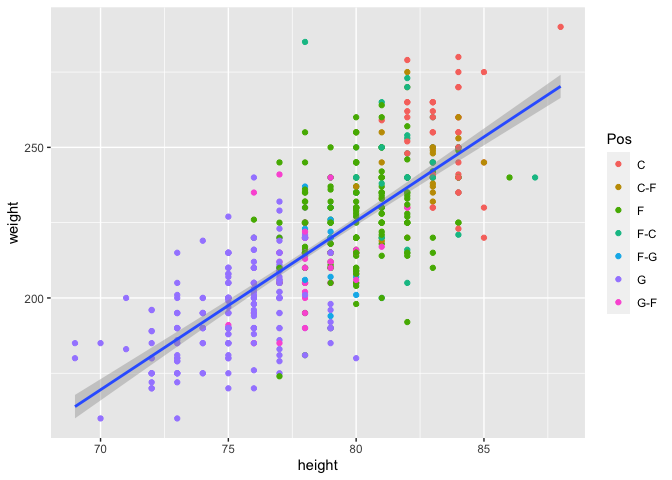

```r
ggplot(test, aes(x = height, y = weight)) +
    geom_point(data = test, aes(color = Pos)) +
    geom_smooth(method='lm')
```

Let’s break it down into pieces:

```
ggplot(test, aes(x = height, y = weight))
```

This tells ggplot that the data is called test and the aesthetic (aes) informs ggplot about the appearance of the graphic, that is, height on the x-axis and weight on the y-axis. If you only ran that line, there would be no error, but there would be no graphic either.

To generate a graphic in ggplot, one must include a geom_ a geom indicates the display. In this case, we are using geom_point which will yield a scatterplot:

```
ggplot(test, aes(x = height, y = weight)) +
    geom_point(data = test, aes(color = Pos))
```

notice the “+” sign. It is used to layer or make additions to the ggplot specifications. See the result of those two lines:

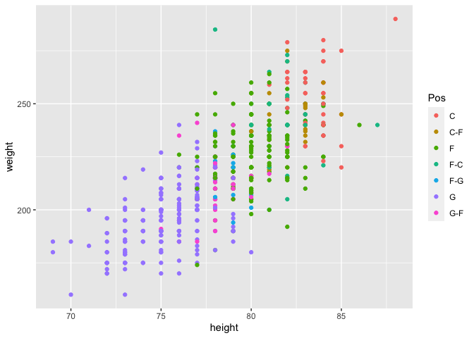

```r
ggplot(test, aes(x = height, y = weight)) +
    geom_point(data = test, aes(color = Pos))
```

We can add as many geoms as we like to a graphic (but it may start to look terrible…) by using the “+”, so here, we add a regression line.

```
ggplot(test, aes(x = height, y = weight)) +
    geom_point(data = test, aes(color = Pos)) +
    geom_smooth(method='lm')
```

The usual question that comes up is “why are there two aes() in this plot” and "why didn’t you put the aes(color = Pos) in the first aes()?

If I had made the choice to put color in the “global aesthetic” (I can’t think of a better description of the first one) we would get this result instead (it’s not wrong, just not what I wished to create):

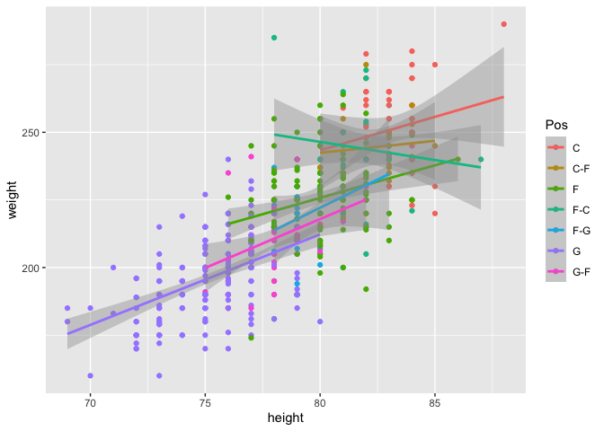

```r
ggplot(test, aes(x = height, y = weight, color = Pos)) +
    geom_point() +
    geom_smooth(method='lm')
```

For problem 1, based on what you have learned so far, please create a scatterplot like this one. I logged the salary values with y = log(`Salary2019-20`) and I used the package ggthemes to make my graph look more like something created by Google Docs (but you don’t need to):

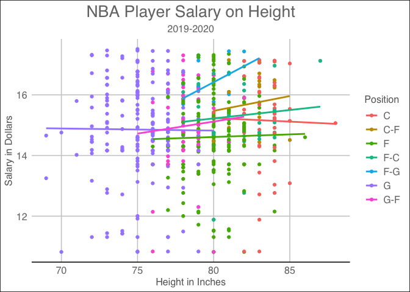

# 2. Boxplots (one numeric and one non-numeric variable)

Boxplots were developed pre-computers for quick summaries and comparisons. My initial boxplot of 2019-2020 NBA salaries by team is technically correct and informative. However, it is unattractive to the point where a story could be obscured.

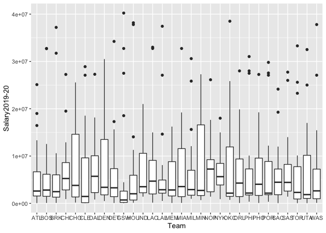

```r
ggplot(test, aes(x = Team, y = `Salary2019-20`)) +
    geom_boxplot()
```

Suppose you were submitting an application to the NBA for a summer intern-analyst position and one part of the submission requested a demonstration of your visualization skills. Before programming, have a sketch in mind regarding what you could add to the boxplot graphic to make it more informative (e.g., titles) and/or more polished in it’s appearance. Here’s my quick and very dirty… you can use parts of the code for problem 2, but don’t copy it verbatim, the point is to give you a start by showing you some non-intuitive things that can be done with R and ggplot2 (e.g., multiple geoms of the same type, multiple themes):

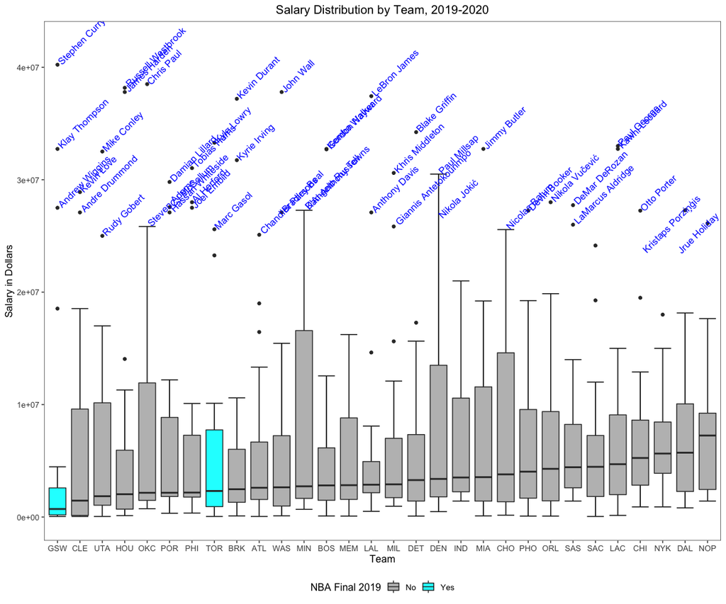

```r
## we won't be writing our own custom functions until Week 5 but you can see
## they are handy, I'm writing my own outlier test function
is_outlier <- function(x) {
  return(x < quantile(x, 0.25) - 2 * IQR(x) | x > quantile(x, 0.75) + 2 * IQR(x))
}

## modify the data, recall %>% is interpreted as "then"
## I created separate outliers for the teams DAL and NOP because I needed
## to print them differently to fit them on the graphic
## it is inefficient, but it gives me the "look" I want in little time.
test <- test %>%
  mutate(final = ifelse(Team %in% c("GSW", "TOR"),"Yes","No"),
         outlier = ifelse(is_outlier(`Salary2019-20`) &
                            !(Team %in% c("DAL", "NOP")), Player, as.numeric(NA)),
         outlier2 = ifelse(is_outlier(`Salary2019-20`) &
                             Team %in% c("DAL", "NOP"),
                             Player, as.numeric(NA)))
## now create the boxplot
ggplot(test, aes(x = reorder(Team, `Salary2019-20`, FUN = median),
                 y = `Salary2019-20`,
                 fill = final)) +
    stat_boxplot(geom = "errorbar", width = 0.75, coef = 1.5) +
    geom_boxplot() +
    scale_fill_manual(values=c("grey", "cyan"),
                      name = "NBA Final 2019") +
    geom_text(aes(label = outlier), na.rm = TRUE, size = 4,
              angle = 45, hjust = -0.05, color = "blue") +
    geom_text(aes(label = outlier2), na.rm = TRUE, size = 4,
              angle = 45, hjust = 0.75, color = "blue") +
    ylim(0, 42000000) +
    labs(title="Salary Distribution by Team, 2019-2020",
        x ="Team", y = "Salary in Dollars") +
    theme_few() +
    theme(plot.title = element_text(hjust = 0.5),
          legend.position="bottom")
```

For Problem 2, I’d like you to use the NBA data to create a boxplot using ggplot2, you don’t need to copy my example (it is dull), you can create your own, but remember to choose one categorical (grouping) variable and one numeric (analysis) variable at minimum. Your graphic should be appropriately labeled.

# 3. Histogram (one numeric variable)

Please demonstrate that you are able to put three plots on a single graphic using R (not photoshop etc.) by drawing histograms of yelp ratings for Vegan, Buffets and Sports Bars as demonstrated below. Use the dataset http://www.stat.ucla.edu/~vlew/datasets/yelp3.csv The colors used were orange, blue and maroon and those are densities on the y-axis (not frequencies). I adjusted the fig.height= in R Markdown so the result would look less “squished”.

You will need an extra package – gridExtra – to make 3 individual ggplots become a single graphic:

[figure not shown]

# 4. Line Graph (numeric variables)

Increasingly these have a time dimension and it’s increasingly an important component of data. So while I haven’t lectured on time, it’s not difficult, we’ve seen this data before. The only twist is the need to “pivot” the data from wide format (AAPL) to long format (AAPL2020). In other words, this graph requires more data wrangling to get the right look:

```r
AAPL
```

```
## # A tibble: 1,259 x 7
##    Date        Open  High   Low Close `Adj Close`    Volume
##    <date>     <dbl> <dbl> <dbl> <dbl>       <dbl>     <dbl>
##  1 2015-07-09  124.  124.  119.  120.        111.  78595000
##  2 2015-07-10  122.  124.  121.  123.        114.  61354500
##  3 2015-07-13  125.  126.  124.  126.        116.  41440500
##  4 2015-07-14  126.  126.  125.  126.        116.  31768100
##  5 2015-07-15  126.  127.  126.  127.        117.  33649200
##  6 2015-07-16  128.  129.  127.  129.        118.  36222400
##  7 2015-07-17  129.  130.  128.  130.        119.  46164700
##  8 2015-07-20  131.  133.  131.  132.        122.  58900200
##  9 2015-07-21  133.  133.  130.  131.        121.  76756400
## 10 2015-07-22  122.  126.  122.  125.        115. 115450600
## # … with 1,249 more rows
```

To make things a little simpler, we rid ourselves of what we don’t need (the other rows and a couple of useless variables) and use the pivot_longer() function to restructure the data:

```r
AAPL2020 <- AAPL %>%
    slice(1227:1256) %>%  ## heh, slicing apple...
    select(Date, Open, High, Low, Close) %>%
    pivot_longer(-Date, names_to = "status", values_to = "price")
AAPL2020
```

```
## # A tibble: 120 x 3
##    Date       status price
##    <date>     <chr>  <dbl>
##  1 2020-05-21 Open    319.
##  2 2020-05-21 High    321.
##  3 2020-05-21 Low     316.
##  4 2020-05-21 Close   317.
##  5 2020-05-22 Open    316.
##  6 2020-05-22 High    319.
##  7 2020-05-22 Low     315.
##  8 2020-05-22 Close   319.
##  9 2020-05-26 Open    324.
## 10 2020-05-26 High    324.
## # … with 110 more rows
```

this data format is also called “stacked data”. For multiple line plots (or multiple anything really) ggplot prefers this structure:

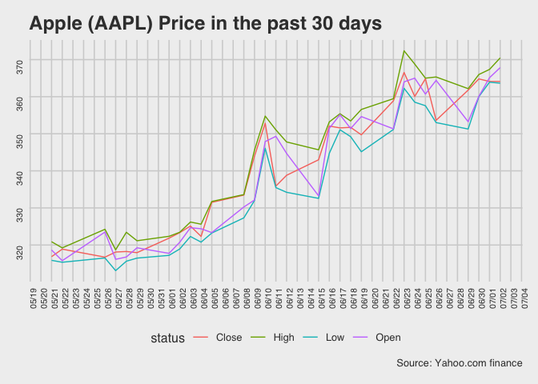

```r
ggplot(data=AAPL2020, aes(x = Date, y = price, color = status)) +
  geom_line() +
  labs(title="Apple (AAPL) Price in the past 30 days",
       caption="Source: Yahoo.com finance",
       y="Price in Dollars") +
  scale_x_date(date_breaks = "days" ,date_labels = "%m/%d") +
  theme_fivethirtyeight() +
  theme(axis.text=element_text(size=8, angle = 90))
```

The graph is not difficult to draw. A good exercise is to go and retrieve 30 days (or more if you are interested) of data from https://finance.yahoo.com/lookup and choose a different stock to use to make a line graph with multiple lines and colors. Some ticker symbols are

COST – Costco  
MSFT – Microsoft  
WMT – Wal-Mart  
GOOG – Google  
NFLX – NetFlix

# 5. What to Turn in For Credit

- Graphics and code for those graphics for Questions 1-4 using ggplot to generate the graphics.
- Name your file Lastname_Firstname_Lesson09.Rmd a model appears in the next link
- Submit your .Rmd file and your .html knitted/rendered result to the appropriate link in Week 3 no later than 7/18/2020 11:59PM PDT. Lessons are not late until they are downloaded for grading, so you can submit after the due date without penalty for a while.